# Lab 5 - Time-varying productivity of salmon

Dynamic Linear Models (DLMs)

Person 1, Person 2, Person 3

May 11, 2023

# General tasks

Use the information and data in the previous section to answer the following questions. Note that if any model is not converging, then you will need to increase the `maxit` parameter in the `control` argument/list that gets passed to `MARSS()`. For example, you might try `control=list(maxit=2000)`.

1. Begin by fitting a reduced form of Ricker’s model that includes only a time-varying level ($\alpha_t$) and observation error ($v_t$). That is,

$$\begin{align*}
\text{log}(R_t) &= \alpha_t + \text{log}(S_t) + v_t \\
\text{log}(R_t/S_t) &= \alpha_t + v_t
\end{align*}$$

This model assumes no density-dependent survival in that the number of recruits is an ascending function of spawners. Plot the ts of $\alpha_t$ and note the AICc for this model. Also plot appropriate model diagnostics.

2. Fit the full Ricker model with a time-varying intercept and a static effect of spawners. For this model, obtain the time series of $\alpha_t$, which is an estimate of the stock productivity in the absence of density-dependent effects. How do these estimates of productivity compare to those from the previous question? Plot the ts of $\alpha_t$ and note the AICc for this model. Also plot appropriate model diagnostics. ($Hint$: If you don’t want a parameter to vary with time, what does that say about its process variance?)
3. Fit the expanded model that includes the summer PDO index as the covariate (`pdo_summer_t2`). What is the mean level of productivity? Plot the ts of $\delta_t$ and note the AICc for this model. Also plot appropriate model diagnostics.
4. Fit the expanded model that includes the winter PDO index as the covariate (`pdo_winter_t2`). What is the mean level of productivity? Plot the ts of $\delta_t$ and note the AICc for this model. Also plot appropriate model diagnostics.
5. Based on AICc, which of the models above is the most parsimonious? Is it well behaved (i.e., are the model assumptions met)? Plot the model forecasts for the best model. Is this a good forecast model?
6. Consider other environmental factors that could influence the time-varying intrinsic productivity of these salmon. For example, are there other large-scale indices of ocean conditions (e.g., sea-surface temperature, El Niño Southern Oscillation)? You could also consider the possible influence of other salmon stocks such as those we examined in Lab 1.

# Methods

## Environmental covariates

- What environmental or dummy variables did you include and why?

## Models in matrix form

We fit the following four models:

Model 1: Reduced Ricker model
$$\begin{equation}
y_t = \begin{bmatrix}1\end{bmatrix}\begin{bmatrix}
\alpha \\
\end{bmatrix}_t + v_t \\
\begin{bmatrix}
\alpha \\
\end{bmatrix}_t \ =
\begin{bmatrix}
\alpha \\
\end{bmatrix}_{t-1} + \begin{bmatrix}
w_{\alpha} \\
\end{bmatrix}_t
\end{equation}$$

Model 2: Full Ricker model

$$\begin{equation}
y_t = \begin{bmatrix}
1 &
S_t
\end{bmatrix}\begin{bmatrix}
\alpha \\
\beta
\end{bmatrix}_t + v_t \\
\begin{bmatrix}
\alpha \\
\beta
\end{bmatrix}_t =
\begin{bmatrix}
\alpha \\
\beta
\end{bmatrix}_{t-1} +
\begin{bmatrix}
w_{\alpha} \\
w_{\beta}
\end{bmatrix}_t
\end{equation}$$

Model 3: Full Ricker model w/ summer pdo as a covariate

$$\begin{equation}
y_t = \begin{bmatrix}
1 &
S_t &
PDOsummer_t
\end{bmatrix}\begin{bmatrix}
\alpha \\
\beta \\
\delta\\
\end{bmatrix}_t + v_t \\
\begin{bmatrix}
\alpha \\
\beta \\
\delta \\
\end{bmatrix}_t =
\begin{bmatrix}
\alpha \\
\beta \\
\delta \\
\end{bmatrix}_{t-1} +
\begin{bmatrix}
w_{\alpha} \\
w_{\beta} \\
w_{\delta} \\
\end{bmatrix}_t
\end{equation}$$
Model 3: Full Ricker model w/ winter pdo as a covariate

$$\begin{equation}
y_t = \begin{bmatrix}
1 &
S_t &
PDOwinter_t
\end{bmatrix}\begin{bmatrix}
\alpha \\
\beta \\
\delta\\
\end{bmatrix}_t + v_t \\
\begin{bmatrix}
\alpha \\
\beta \\
\delta \\
\end{bmatrix}_t =
\begin{bmatrix}
\alpha \\
\beta \\
\delta \\
\end{bmatrix}_{t-1} +
\begin{bmatrix}
w_{\alpha} \\
w_{\beta} \\
w_{\delta} \\
\end{bmatrix}_t
\end{equation}$$

## Model diagnositics

- What sort of model diagnostics did you use to examine model assumptions?

# Data

Describe the salmon data and any environmental covariates you decide to examine.

## Load the data

```r
## library(devtools)
## Windows users will likely need to set this
#Sys.setenv("R_REMOTES_NO_ERRORS_FROM_WARNINGS" = "true")
#devtools::install_github("nwfsc-timeseries/atsalibrary")

library(tidyverse)
library(MARSS)
# devtools::install_github("nwfsc-timeseries/atsalibrary")

## get data
data(KvichakSockeye, package="atsalibrary")
SR_data <- KvichakSockeye
head(SR_data)
```

```
## # A tibble: 6 × 5
## # Groups:   brood_year [6]
##   brood_year spawners recruits pdo_summer_t2 pdo_winter_t2
##        <dbl>    <dbl>    <dbl>         <dbl>         <dbl>
## 1       1952       NA    20200         -2.79         -1.68
## 2       1953       NA      593         -1.2          -1.05
## 3       1954       NA      799         -1.85         -1.25
## 4       1955       NA     1500         -0.6          -0.68
## 5       1956     9440    39000         -0.5          -0.31
## 6       1957     2840     4090         -2.36         -1.78
```

The data are a dataframe with columns for brood year (`brood_year`), number of spawners (`spawners`), number of recruits (`recruits`) and PDO at year $t-2$ in summer (`pdo_summer_t2`) and in winter (`pdo_winter_t2`).

## Wrangle the data

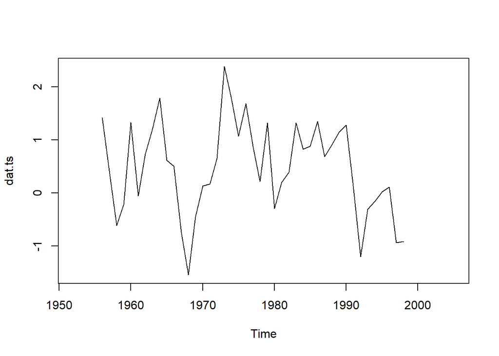

```r
#create log ratio for yt
SR_data$y <- log(SR_data$recruits/SR_data$spawners)

#date to columns
dat <- t(SR_data)
colnames(dat) <- SR_data$brood_year
dat <- dat[-1,]
dat <- dat[c(5,1,3,4,2),]

## plot response variable
dat.ts <- ts(log(SR_data$recruits/SR_data$spawners), start = 1952, end = 2005, frequency =1)
plot.ts(dat.ts)
```

# Results

## Reduced Ricker

1. We first fit a reduced form of Ricker’s model that includes only a time-varying level ($\alpha_t$) and observation error ($v_t$). That is,

$$\begin{align*}
\text{log}(R_t) &= \alpha_t + \text{log}(S_t) + v_t \\
\text{log}(R_t/S_t) &= \alpha_t + v_t
\end{align*}$$

This model assumes no density-dependent survival in that the number of recruits is an ascending function of spawners.

```r
# NO density dependence / stochastic level

mod1 <- list(
  Z = "identity",
  U="zero",
  R=matrix("r",nrow=1),
  B="identity",
  A="zero",
  Q=matrix("q",nrow=1)
)

m1 <- MARSS(dat[1,],model = mod1)
```

```
## Success! abstol and log-log tests passed at 29 iterations.
## Alert: conv.test.slope.tol is 0.5.
## Test with smaller values (<0.1) to ensure convergence.
##
## MARSS fit is
## Estimation method: kem
## Convergence test: conv.test.slope.tol = 0.5, abstol = 0.001
## Estimation converged in 29 iterations.
## Log-likelihood: -52.53672
## AIC: 111.0734   AICc: 111.6888
##
##       Estimate
## R.r      0.228
## Q.q      0.281
## x0.x0    0.952
## Initial states (x0) defined at t=0
##
## Standard errors have not been calculated.
## Use MARSSparamCIs to compute CIs and bias estimates.
```

### $\alpha_t$ plot and the AICc.

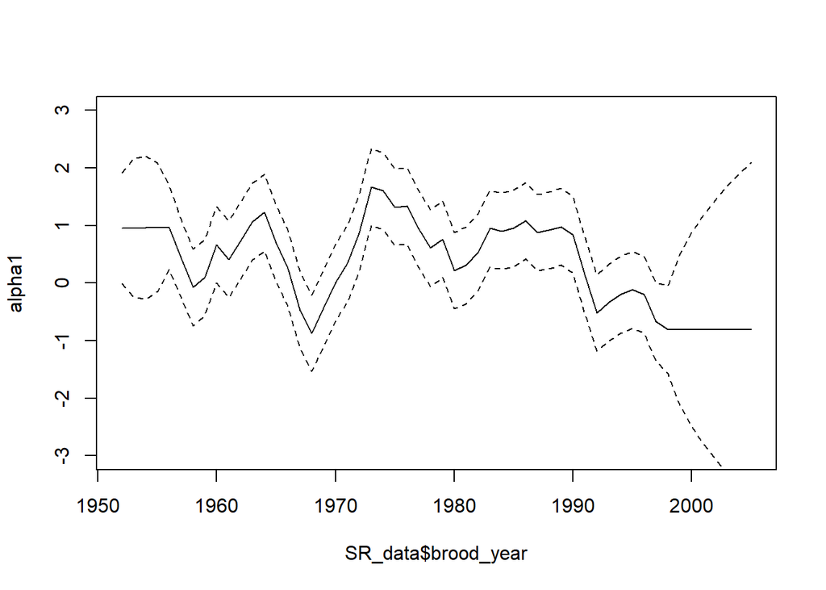

```r
#plot alpha values
alpha1 <- as.numeric(m1$states)
alpha.se1 <- as.numeric(m1$states.se)
plot(alpha1~SR_data$brood_year,type='l', ylim=c(-3,3))
lines(alpha1+2*alpha.se1~SR_data$brood_year, lty="dashed")
lines(alpha1-2*alpha.se1~SR_data$brood_year, lty="dashed")
```

```r
#AICc value
m1$AICc
```

```
## [1] 111.6888
```

The AICc of our first model is 111.688.

### Model diagnostics

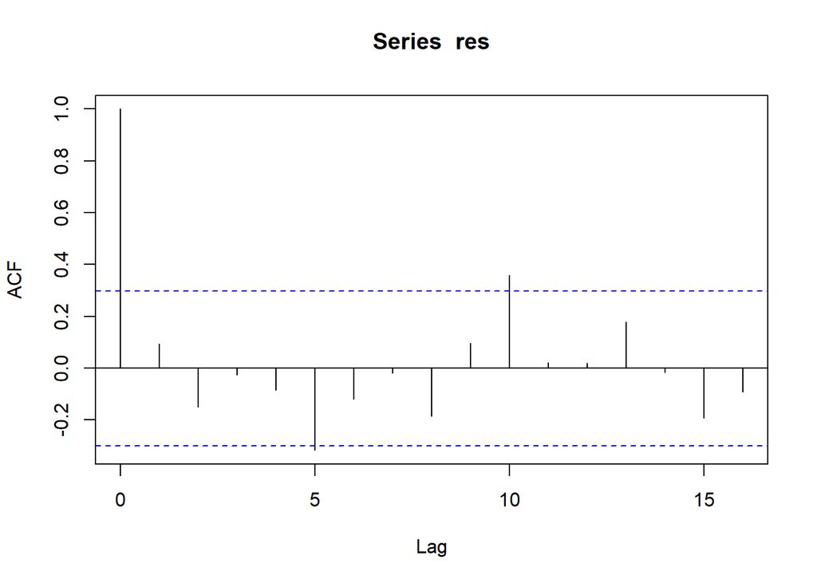

```r
#plot model residuals diagnostics.
res <- residuals(m1)[,7]
tmp <- which(!is.na(res))
res <- res[tmp]
acf(res)
```

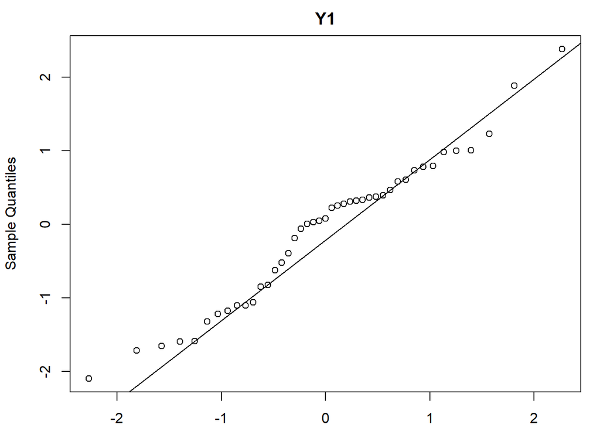

```
## plot type = qqplot.std.model.resids.ytt1
```

```r
#or
#autoplot.marssMLE(m1)

plot(m1, plot.type = "qqplot.std.model.resids.ytt1")
```

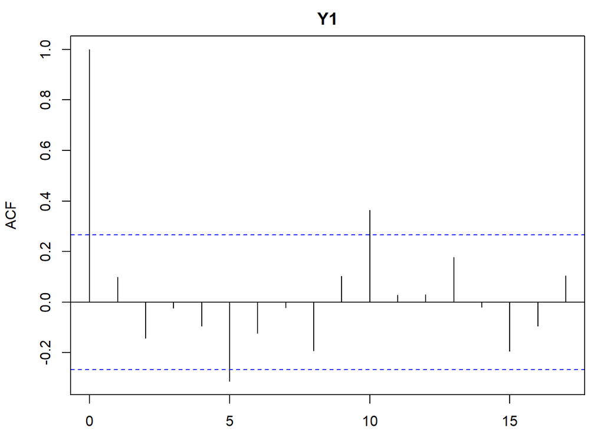

```
## plot type = acf.std.model.resids.ytt1
```

```r
plot(m1, plot.type = "acf.std.model.resids.ytt1")
```

This simplified model show some signs of autocorrelation in residuals.

## Full Ricker Model

We then fit the full Ricker model with a time-varying intercept and a static effect of spawners.

```r
#we model the underlying states of alpha (brood-year productivity) and beta
#beta is prevented from changing.

spawn <- matrix(dat[2,-c(1:4)],nrow=1)    #not sure if we should scale this or not
ratio <- SR_data$y[-c(1:4)]               #remove responses that corresponded to Spawner = NA

m <- 2                     #number of parameters in process
TT <- length(spawn)      #number of data points

B <-  diag(m)                         #"identity"
U <-  matrix(0, nrow = m, ncol = 1)   #"zero"
Q <- matrix(list("q.alpha", 0, 0, 0), nrow = 2)  # Setting the effect of spawners to static
Z <- array(NA, c(1, m, TT))  ## NxMxT; empty for now
Z[1,1,] <- rep(1, TT)        ## Nx1; 1's for intercept
Z[1,2,] <- spawn            ## Nx1; predictor variable
A = matrix(0)            #"zero"
R <-  matrix("r")

inits_list <- list(x0 = matrix(c(0, 0), nrow = m))
mod_list <- list(B = B, U = U, Q = Q, Z = Z, A = A, R = R)

## fit the model with MARSS
m2 <- MARSS(ratio, mod_list, inits = inits_list)
```

```
## Success! abstol and log-log tests passed at 29 iterations.
## Alert: conv.test.slope.tol is 0.5.
## Test with smaller values (<0.1) to ensure convergence.
##
## MARSS fit is
## Estimation method: kem
## Convergence test: conv.test.slope.tol = 0.5, abstol = 0.001
## Estimation converged in 29 iterations.
## Log-likelihood: -51.81022
## AIC: 111.6204   AICc: 112.6731
##
##           Estimate
## R.r       2.19e-01
## Q.q.alpha 2.92e-01
## x0.X1     9.35e-01
## x0.X2     7.02e-06
## Initial states (x0) defined at t=0
##
## Standard errors have not been calculated.
## Use MARSSparamCIs to compute CIs and bias estimates.
```

### $\alpha_t$ plot and the AICc.

The time series of $\alpha_t$ for this model is an estimate of the stock productivity in the absence of density-dependent effects. Here we plot the ts of $\alpha_t$ and note the AICc for this model.

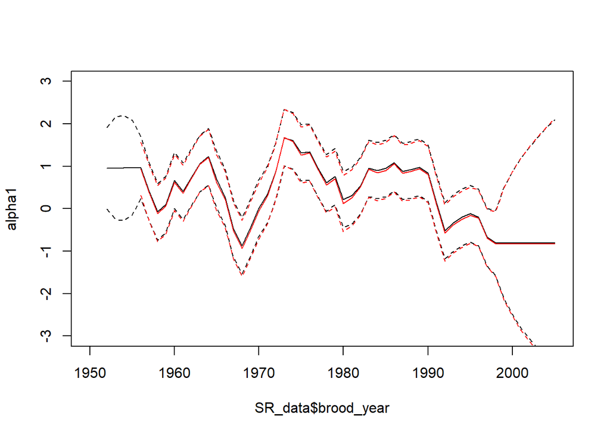

```r
alpha <- as.numeric(m2$states[1,])
beta <- as.numeric(m2$states[2,]) # Here, beta does not time vary (this is the static effect of spawners)
alpha.se <- as.numeric(m2$states.se[1,])
beta.se <- as.numeric(m2$states.se[2,])

#from first model
plot(alpha1~SR_data$brood_year,type='l', ylim=c(-3,3), xlim= c(1950, 2005))
lines(alpha1+2*alpha.se1~SR_data$brood_year, lty="dashed")
lines(alpha1-2*alpha.se1~SR_data$brood_year, lty="dashed")
#second model
lines(alpha~SR_data$brood_year[-c(1:4)],type='l',col="red")
lines(alpha+2*alpha.se~SR_data$brood_year[-c(1:4)], lty="dashed", col="red")
lines(alpha-2*alpha.se~SR_data$brood_year[-c(1:4)], lty="dashed", col="red")
```

```r
#AIC value
m1$AICc
```

```
## [1] 111.6888
```

```r
m2$AICc  #AICc is within a single point.
```

```
## [1] 112.6731
```

How do these estimates of productivity compare to those from the previous question?

We were expecting the alphas (productivity) from model 2 to be smaller than model 1, however the estimated values of alpha are very similar in each model.

The model AICcs are also very similar and only vary by a single point.

### Model diagnostics

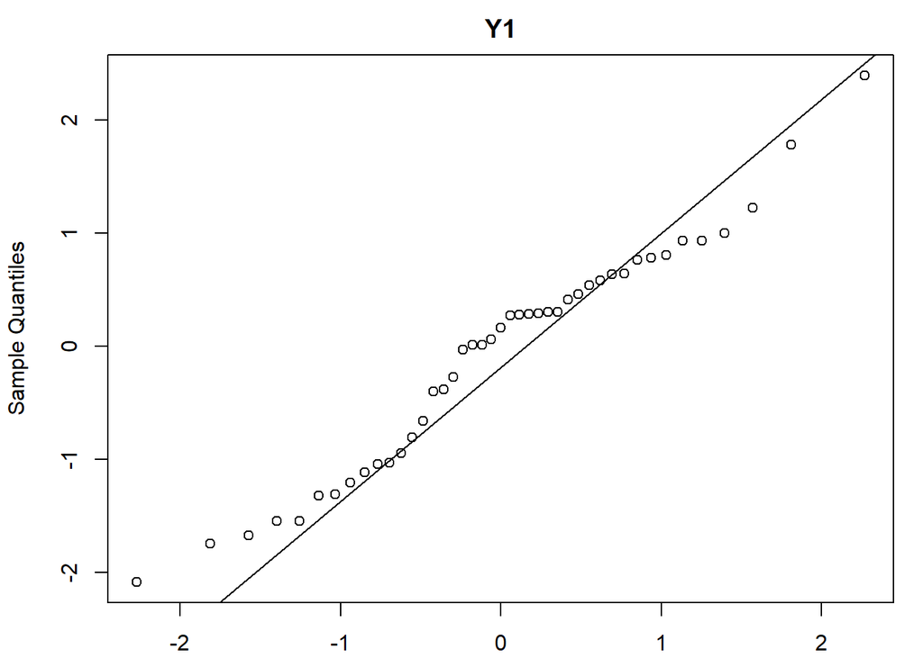

```
## plot type = qqplot.std.model.resids.ytt1
```

```r
#plot model diagnostics.
#autoplot.marssMLE(m2)

plot(m2, plot.type = "qqplot.std.model.resids.ytt1")
```

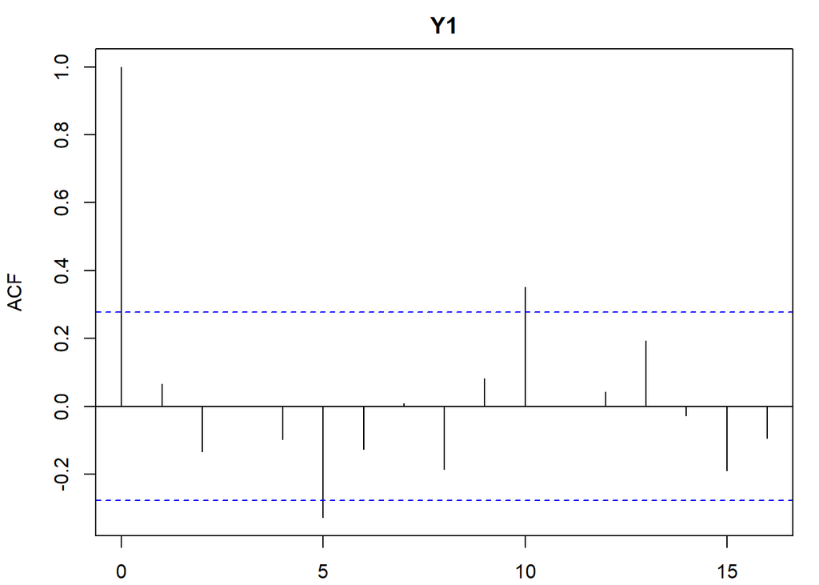

```
## plot type = acf.std.model.resids.ytt1
```

```r
plot(m2, plot.type = "acf.std.model.resids.ytt1")
```

Similar to our first model, the ACF plot still shows a lag at 5 and 10.

## Expanded Ricker with summer PDO

Next we fit the expanded Ricker model including the summer PDO index as the covariate (`pdo_summer_t2`).

NOTES– why do we change the intercept (alpha) to static, why do we change the effect of spawners to vary (beta)?

```r
#first model we assume there is no density dependence
#we model the underlying states of alpha (brood-year productivity) and beta
#beta is prevented from changing.

pdo_s <- matrix(dat[3,-c(1:4)], nrow=1)

m <- 3                     #number of parameters in process
TT <- length(spawn)      #number of data points

B <-  diag(m)                         #"identity"
U <-  matrix(0, nrow = m, ncol = 1)   #"zero"
Q <- matrix(list("q.alpha", 0,0,              #we no longer want alpha to vary
                 0, 0,0,  #Do we want beta to vary now?
                 0,0,"q.pdo_s"), nrow = 3, byrow = TRUE)  # to have characters and numbers in same matrix use a list
Z <- array(NA, c(1, m, TT))  ## NxMxT; empty for now
Z[1,1,] <- rep(1, TT)        ## Nx1; 1's for intercept
Z[1,2,] <- spawn           ## Nx1; predictor variable spawners
Z[1,3,] <-  pdo_s            ## Nx1; predictor PDO summer
A = matrix(0)                #"zero"
R <-  matrix("r")

inits_list2 <- list(x0 = matrix(c(0,0,0), nrow = m))
mod_list2 <- list(B = B, U = U, Q = Q, Z = Z, A = A, R = R)
cont_list <- list(maxit=10000)
# run model
m3 <- MARSS(ratio, mod_list2, inits = inits_list2, method = "BFGS")
```

```
## Success! Converged in 97 iterations.
## Function MARSSkfas used for likelihood calculation.
##
## MARSS fit is
## Estimation method: BFGS
## Estimation converged in 97 iterations.
## Log-likelihood: -51.78324
## AIC: 115.5665   AICc: 117.8998
##
##           Estimate
## R.r       2.00e-01
## Q.q.alpha 3.17e-01
## Q.q.pdo_s 1.73e-14
## x0.X1     1.01e+00
## x0.X2     5.49e-06
## x0.X3     2.85e-02
## Initial states (x0) defined at t=0
##
## Standard errors have not been calculated.
## Use MARSSparamCIs to compute CIs and bias estimates.
```

What is the mean level of productivity?

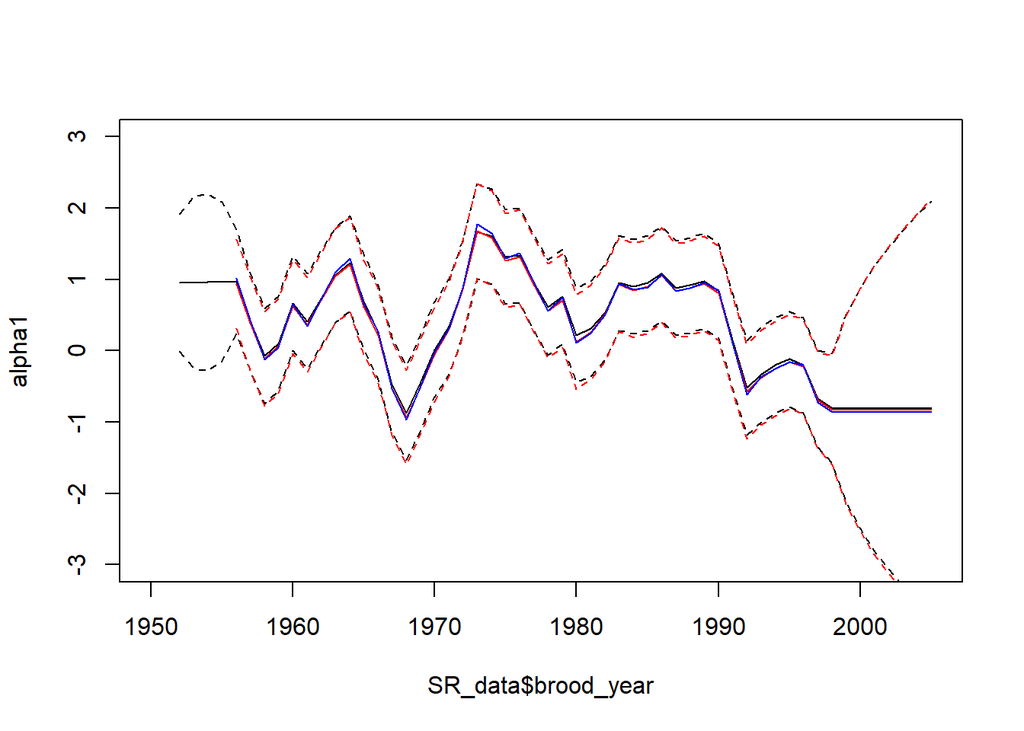

```r
alpha3 <- as.numeric(m3$states[1,])  #static number
beta3 <- as.numeric(m3$states[2,])
pdo_s <- as.numeric(m3$states[3,])

beta.se3 <- as.numeric(m3$states.se[2,])
pdo_s.se3 <- as.numeric(m3$states.se[3,])


#from first model
plot(alpha1~SR_data$brood_year,type='l', ylim=c(-3,3), xlim= c(1950, 2005))
lines(alpha1+2*alpha.se1~SR_data$brood_year, lty="dashed")
lines(alpha1-2*alpha.se1~SR_data$brood_year, lty="dashed")
#second model
lines(alpha~SR_data$brood_year[-c(1:4)],type='l',col="red")
lines(alpha+2*alpha.se~SR_data$brood_year[-c(1:4)], lty="dashed", col="red")
lines(alpha-2*alpha.se~SR_data$brood_year[-c(1:4)], lty="dashed", col="red")
#third model
lines(alpha3~SR_data$brood_year[-c(1:4)],type='l', col="blue")
```

```r
m1$states[-c(1:4)] #alpha from model 1 trimmed to same length as model 2 for comparison
```

```
##  [1]  0.96768907  0.41504542 -0.07559988  0.09957993  0.66572593  0.41102136
##  [7]  0.73469887  1.06271995  1.22760763  0.69548408  0.26109217 -0.47323645
## [13] -0.87371945 -0.43990780  0.01784553  0.33968848  0.87191889  1.67428170
## [19]  1.60321781  1.31753061  1.33987068  0.93953843  0.60900628  0.76058590
## [25]  0.21761436  0.30919509  0.53966053  0.95001634  0.90106740  0.94894580
## [31]  1.08056320  0.87788167  0.91717373  0.98016867  0.83743070  0.14769941
## [37] -0.51871543 -0.34144531 -0.20468399 -0.11832377 -0.20219898 -0.67191046
## [43] -0.80922950 -0.80922950 -0.80922950 -0.80922950 -0.80922950 -0.80922950
## [49] -0.80922950 -0.80922950
```

```r
m2$states[1,]      #alpha from model 2
```

```
##  [1]  0.93687677  0.38492602 -0.11351090  0.06306778  0.62042657  0.36572052
##  [7]  0.71126813  1.05442108  1.21313214  0.60717372  0.21671558 -0.52213866
## [13] -0.93477393 -0.50198037 -0.04751330  0.30283846  0.85410371  1.68340757
## [19]  1.58176529  1.26071722  1.31990147  0.91346965  0.56035308  0.70295245
## [25]  0.12188586  0.26371715  0.51157963  0.92734338  0.84922110  0.90504670
## [31]  1.06045139  0.83829287  0.88203397  0.94266491  0.80852443  0.10911945
## [37] -0.57699793 -0.38350912 -0.25223166 -0.16083111 -0.21672970 -0.69599440
## [43] -0.83361454 -0.83361454 -0.83361454 -0.83361454 -0.83361454 -0.83361454
## [49] -0.83361454 -0.83361454
```

```r
m3$states[1,]     #alpha from model 3
```

```
##  [1]  1.01456328  0.43277203 -0.12293425  0.04161336  0.64985647  0.35020908
##  [7]  0.72137765  1.09991480  1.29733813  0.65635620  0.26681983 -0.53165805
## [13] -0.97250801 -0.48592658 -0.02317135  0.31549460  0.87999216  1.77563537
## [19]  1.64858090  1.29918781  1.36825308  0.94561830  0.56281262  0.74843782
## [25]  0.10640414  0.24853099  0.50294685  0.94388001  0.85522517  0.89233555
## [31]  1.07259089  0.83162221  0.87814013  0.95487870  0.85044945  0.11469933
## [37] -0.61207571 -0.37226049 -0.25357439 -0.16095392 -0.19724355 -0.72628320
## [43] -0.86654476 -0.86654476 -0.86654476 -0.86654476 -0.86654476 -0.86654476
## [49] -0.86654476 -0.86654476
```

```r
m2$states[2,]     # beta from model 2
```

```
##  [1] 7.0198e-06 7.0198e-06 7.0198e-06 7.0198e-06 7.0198e-06 7.0198e-06
##  [7] 7.0198e-06 7.0198e-06 7.0198e-06 7.0198e-06 7.0198e-06 7.0198e-06
## [13] 7.0198e-06 7.0198e-06 7.0198e-06 7.0198e-06 7.0198e-06 7.0198e-06
## [19] 7.0198e-06 7.0198e-06 7.0198e-06 7.0198e-06 7.0198e-06 7.0198e-06
## [25] 7.0198e-06 7.0198e-06 7.0198e-06 7.0198e-06 7.0198e-06 7.0198e-06
## [31] 7.0198e-06 7.0198e-06 7.0198e-06 7.0198e-06 7.0198e-06 7.0198e-06
## [37] 7.0198e-06 7.0198e-06 7.0198e-06 7.0198e-06 7.0198e-06 7.0198e-06
## [43] 7.0198e-06 7.0198e-06 7.0198e-06 7.0198e-06 7.0198e-06 7.0198e-06
## [49] 7.0198e-06 7.0198e-06
```

```r
m3$states[2,]     #beta from model 3
```

```
##  [1] 5.486033e-06 5.486033e-06 5.486033e-06 5.486033e-06 5.486033e-06
##  [6] 5.486033e-06 5.486033e-06 5.486033e-06 5.486033e-06 5.486033e-06
## [11] 5.486033e-06 5.486033e-06 5.486033e-06 5.486033e-06 5.486033e-06
## [16] 5.486033e-06 5.486033e-06 5.486033e-06 5.486033e-06 5.486033e-06
## [21] 5.486033e-06 5.486033e-06 5.486033e-06 5.486033e-06 5.486033e-06
## [26] 5.486033e-06 5.486033e-06 5.486033e-06 5.486033e-06 5.486033e-06
## [31] 5.486033e-06 5.486033e-06 5.486033e-06 5.486033e-06 5.486033e-06
## [36] 5.486033e-06 5.486033e-06 5.486033e-06 5.486033e-06 5.486033e-06
## [41] 5.486033e-06 5.486033e-06 5.486033e-06 5.486033e-06 5.486033e-06
## [46] 5.486033e-06 5.486033e-06 5.486033e-06 5.486033e-06 5.486033e-06
```

```r
m3$states[3,]    #estimate of pdo_s coeficient was allowed to vary in Q but was estimated as static
```

```
##  [1] 0.02846597 0.02846597 0.02846597 0.02846597 0.02846597 0.02846597
##  [7] 0.02846597 0.02846597 0.02846597 0.02846597 0.02846597 0.02846597
## [13] 0.02846597 0.02846597 0.02846597 0.02846597 0.02846597 0.02846597
## [19] 0.02846597 0.02846597 0.02846597 0.02846597 0.02846597 0.02846597
## [25] 0.02846597 0.02846597 0.02846597 0.02846597 0.02846597 0.02846597
## [31] 0.02846597 0.02846597 0.02846597 0.02846597 0.02846597 0.02846597
## [37] 0.02846597 0.02846597 0.02846597 0.02846597 0.02846597 0.02846597
## [43] 0.02846597 0.02846597 0.02846597 0.02846597 0.02846597 0.02846597
## [49] 0.02846597 0.02846597
```

```r
#AIC value
m1$AICc
```

```
## [1] 111.6888
```

```r
m2$AICc  #AICc is within a single point.
```

```
## [1] 112.6731
```

```r
m3$AICc  # getting worse
```

```
## [1] 117.8998
```

Plot the ts of $\delta_t$ and note the AICc for this model.

Also plot appropriate model diagnostics.

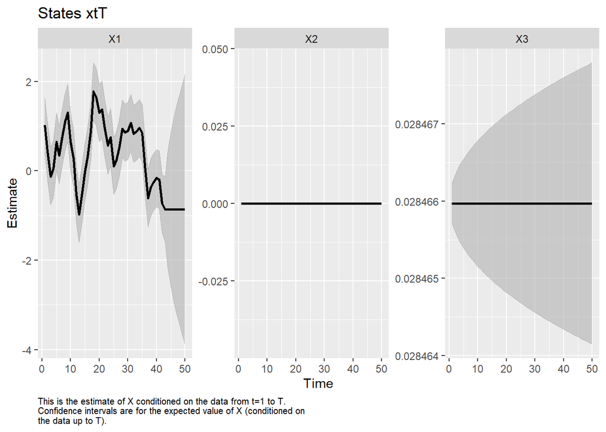

```
## plot.type = xtT
```

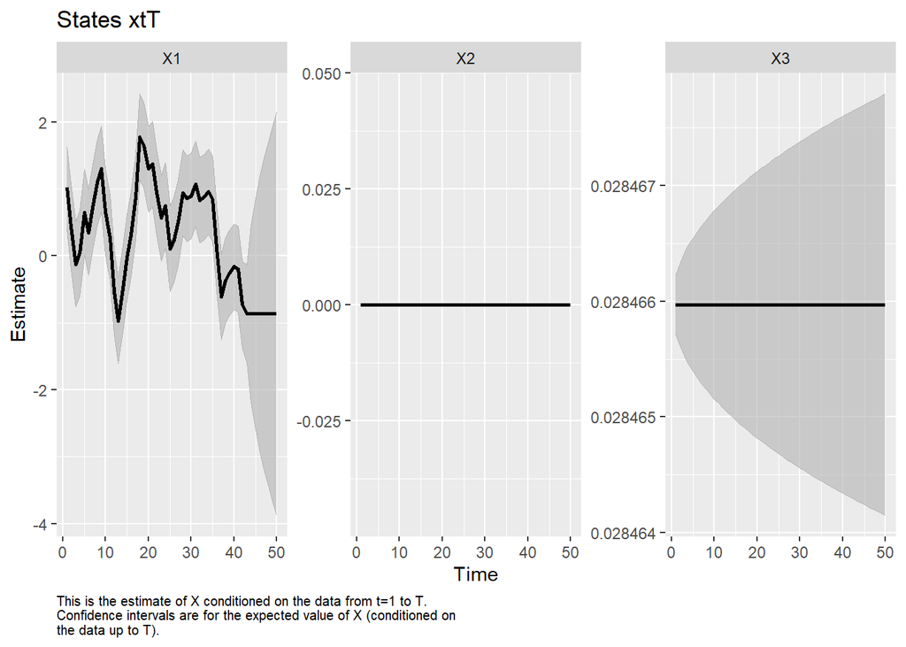

```
## Hit <Return> to see next plot (q to exit):
```

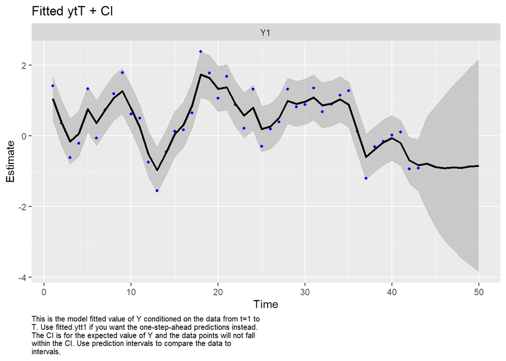

```
## plot.type = fitted.ytT
```

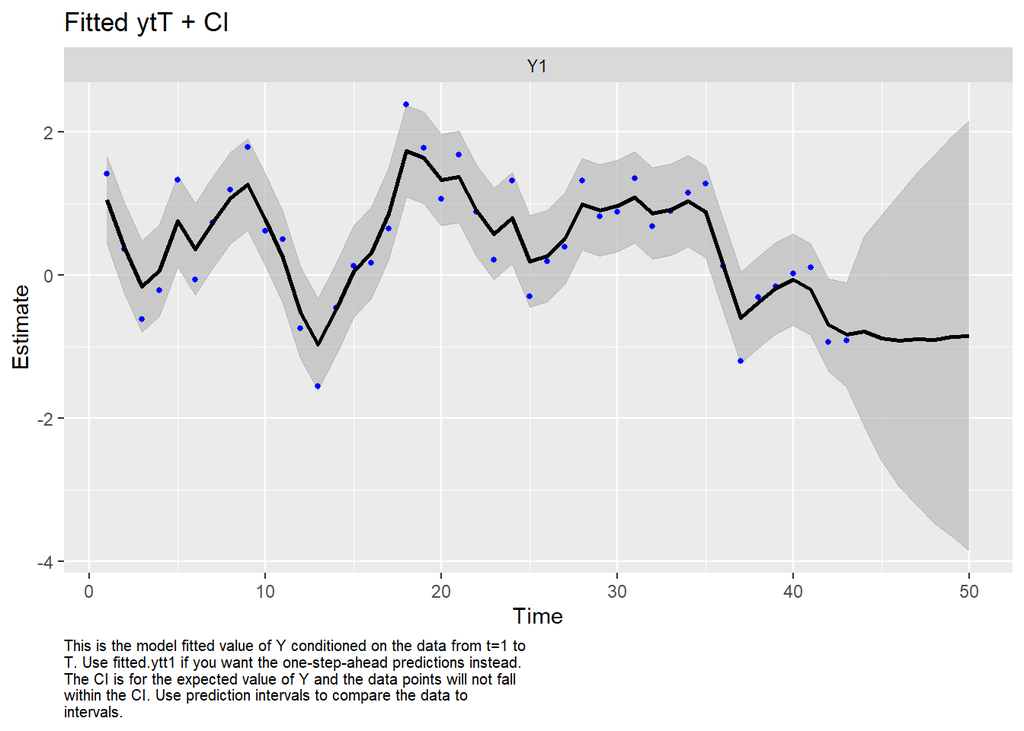

```
## Hit <Return> to see next plot (q to exit):
```

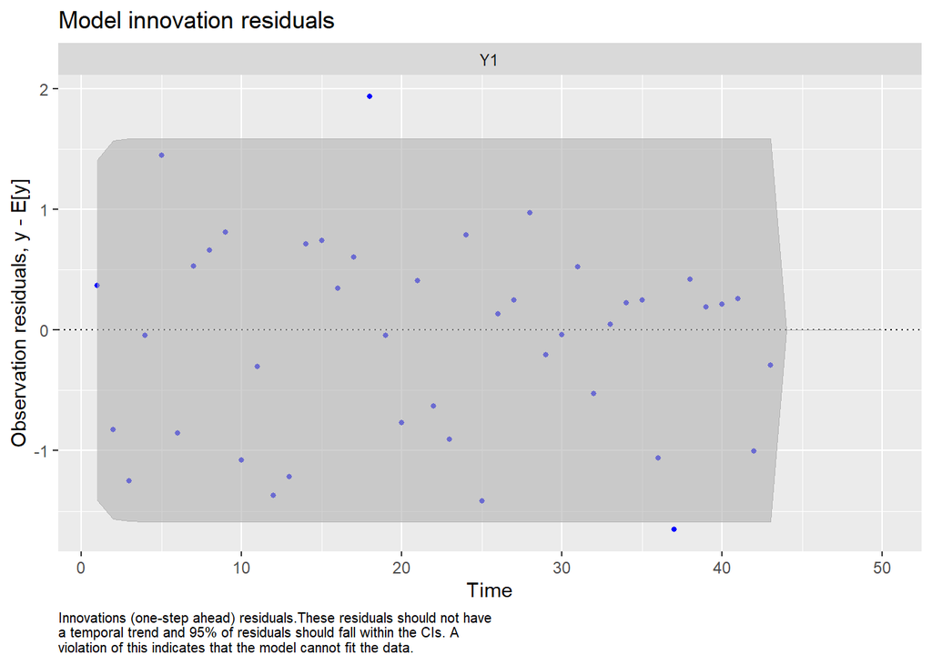

```
## plot.type = model.resids.ytt1
```

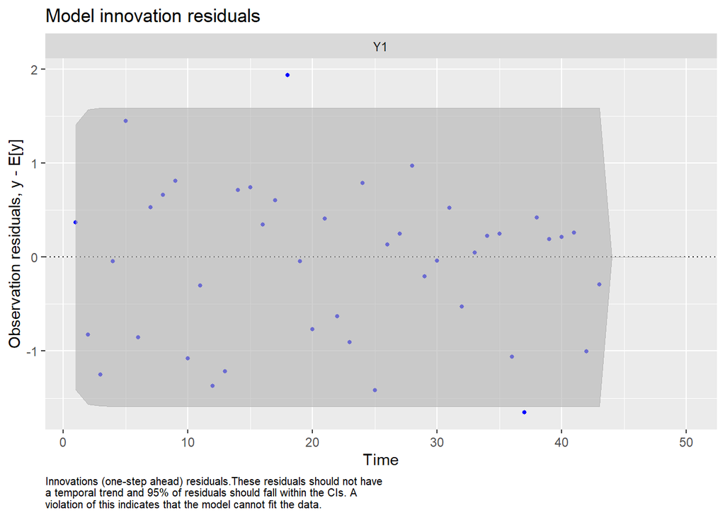

```
## Hit <Return> to see next plot (q to exit):
```

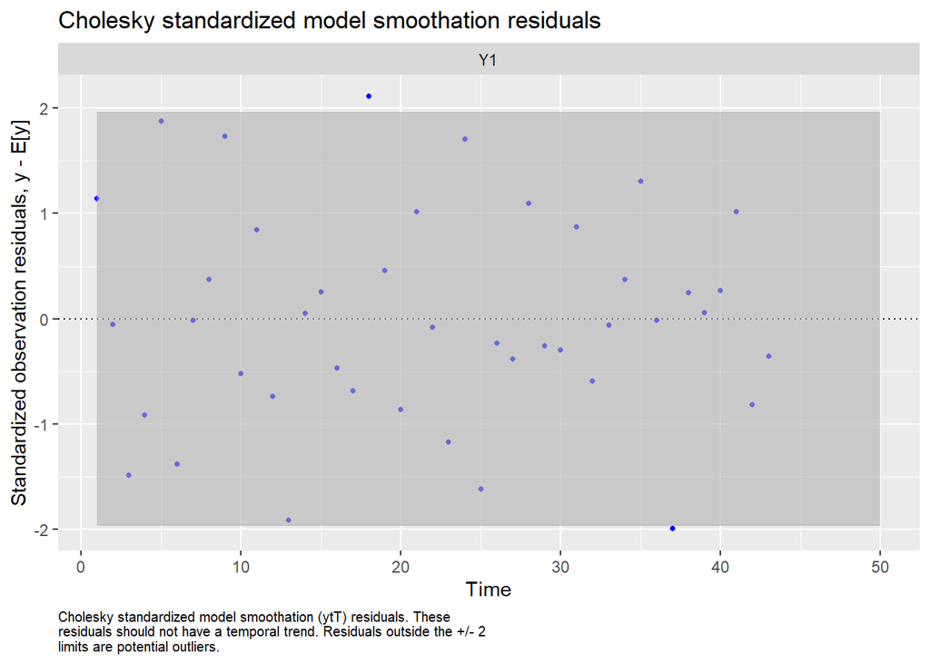

```
## plot.type = std.model.resids.ytT
```

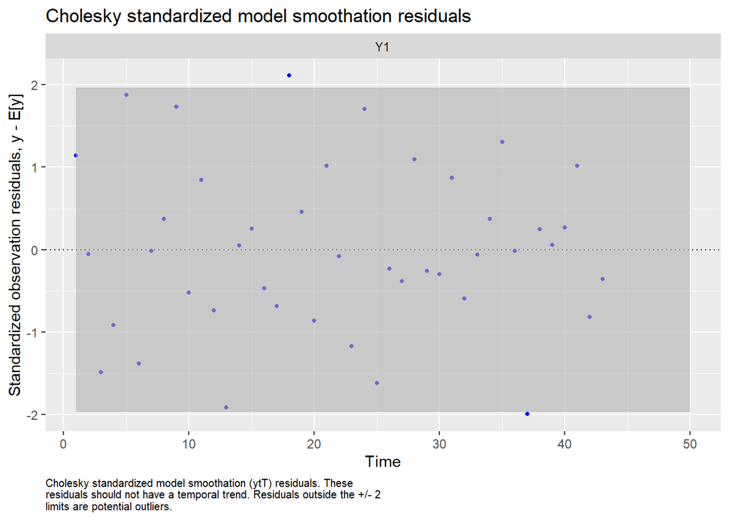

```
## Hit <Return> to see next plot (q to exit):
```

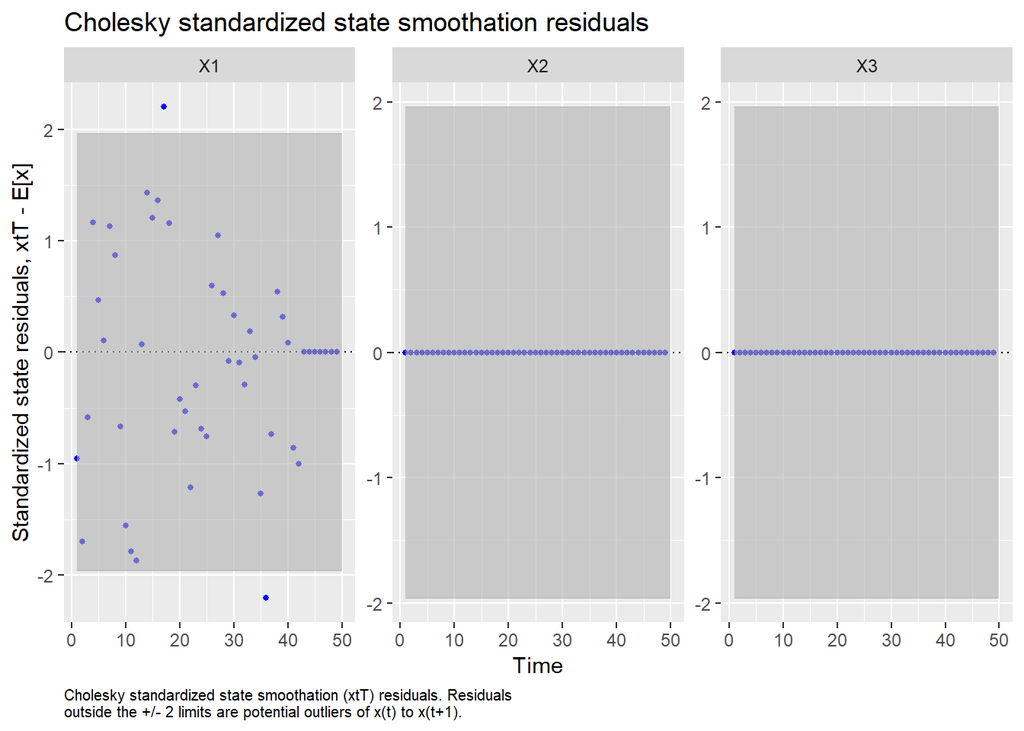

```
## plot.type = std.state.resids.xtT
```

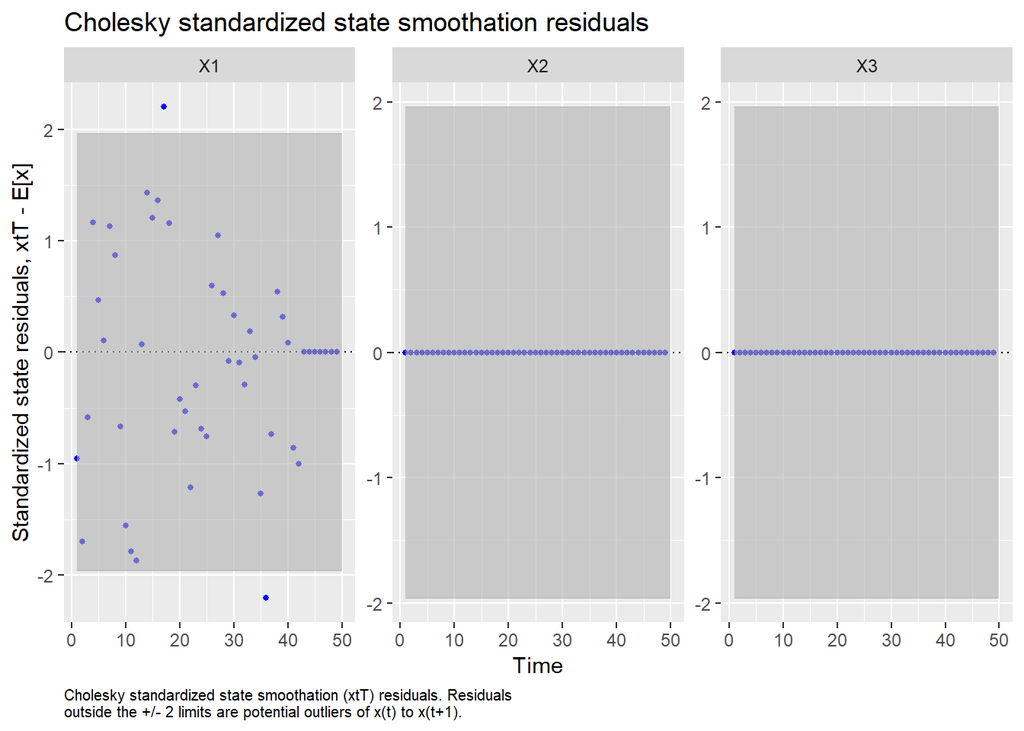

```
## Hit <Return> to see next plot (q to exit):
```

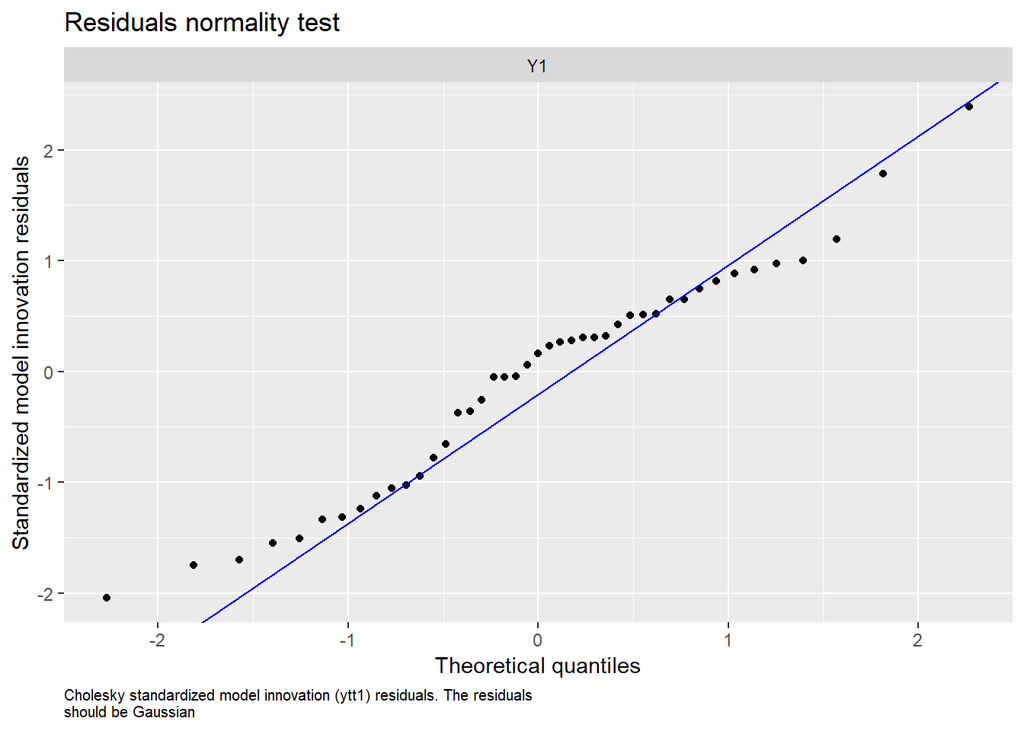

```
## plot.type = qqplot.std.model.resids.ytt1
```

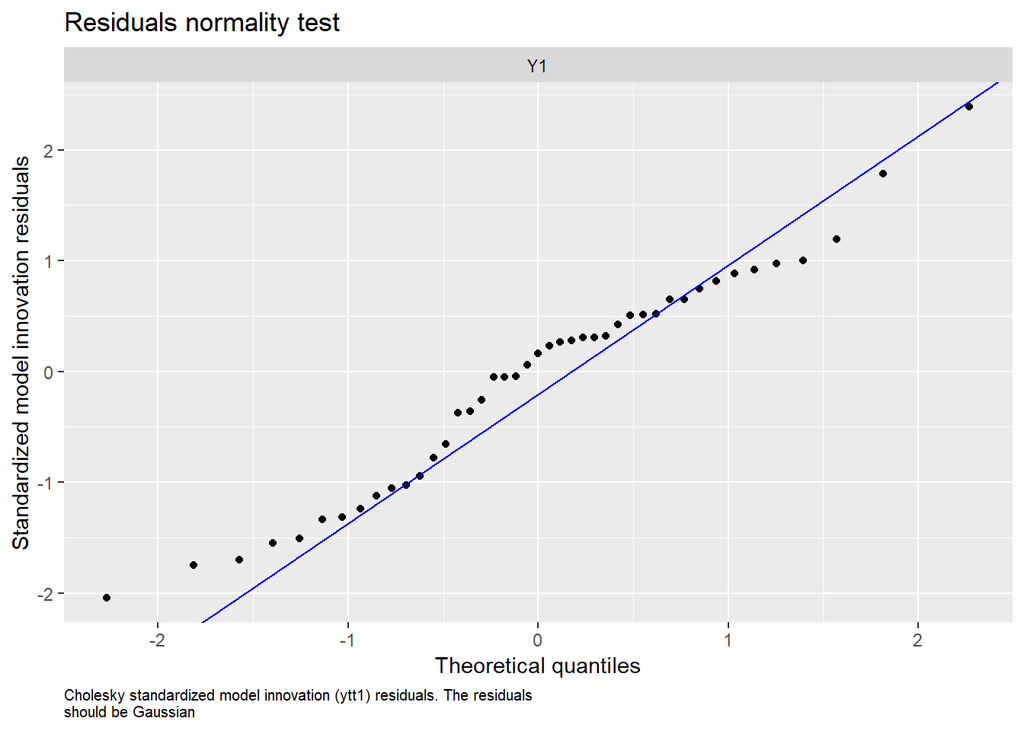

```
## Hit <Return> to see next plot (q to exit):
```

[4 more figures not shown]

```
## Hit <Return> to see next plot (q to exit):
```

```r
autoplot.marssMLE(m3)
```

```r
#more autocorrelations in acf plot
```

## Expanded Ricker with winter PDO

4. Fit the expanded model that includes the winter PDO index as the covariate (`pdo_winter_t2`). What is the mean level of productivity? Plot the ts of $\delta_t$ and note the AICc for this model. Also plot appropriate model diagnostics.

```r
pdo_w <- matrix(dat[4,-c(1:4)], nrow=1)

m <- 3                   #number of parameters in process
TT <- length(spawn)      #number of data points

B <-  diag(m)                         #"identity"
U <-  matrix(0, nrow = m, ncol = 1)   #"zero"
Q <- matrix(list("q.alpha", 0,0,              #we no longer want alpha to vary
                 0, 0,0,  #Do we want beta to vary now?
                 0,0,"q.pdo_w"), nrow = 3, byrow = TRUE) # to have characters and numbers in same matrix use a list
Z <- array(NA, c(1, m, TT))  ## NxMxT; empty for now
Z[1,1,] <- rep(1, TT)        ## Nx1; 1's for intercept
Z[1,2,] <- spawn           ## Nx1; predictor variable spawners
Z[1,3,] <-  pdo_w           ## Nx1; predictor PDO summer
#Z[1,4,] <-  pdo_w            ## Nx1; predictor PDO winter
A = matrix(0)                #"zero"
R <-  matrix("r")

inits_list4 <- list(x0 = matrix(c(0,0,0), nrow = m))
mod_list4 <- list(B = B, U = U, Q = Q, Z = Z, A = A, R = R)
cont_list <- list(maxit=10000)
# run model
m4 <- MARSS(ratio, mod_list4, inits = inits_list4, control = cont_list, method = "BFGS")
```

```
## Success! Converged in 93 iterations.
## Function MARSSkfas used for likelihood calculation.
##
## MARSS fit is
## Estimation method: BFGS
## Estimation converged in 93 iterations.
## Log-likelihood: -51.38573
## AIC: 114.7715   AICc: 117.1048
##
##           Estimate
## R.r       1.96e-01
## Q.q.alpha 3.11e-01
## Q.q.pdo_w 4.17e-12
## x0.X1     1.13e+00
## x0.X2     1.32e-06
## x0.X3     1.54e-01
## Initial states (x0) defined at t=0
##
## Standard errors have not been calculated.
## Use MARSSparamCIs to compute CIs and bias estimates.
```